# Transportation Costs & Trips City

Author

Tina Chelidze

Published

April 25, 2024

*2023-2024 Mobility Metrics update*

SUMMARY-LEVEL VALUES

Raw data pulled from https://htaindex.cnt.org/download/ The Housing and Transportation (H+T) Affordability Index from the Center for Neighborhood Technology (CNT)

*User Notice: This program requires downloading raw files from the Metrics_2024_round Box folder prior to running. See details under the Read Data section.*

## Housekeeping

Read in packages for use.

```r
library(tidyr)
library(dplyr)
library(readr)
library(ggplot2)
library(tidyverse)
library(purrr)
```

## Read data

The data from HUD cannot be easily read directly into this program. Before running, please download the entirety of the folders listed below from the following [Box folder](https://urbanorg.app.box.com/folder/250262697073) into the repository folder. You may be required to unzip the folders but keep the raw files in their folders. `"mobility-from-poverty\06_neighborhoods\Transportation\data"`

- 2015_tract
- 2019_tract

Import all the files (and/or combine into one file) with only the relevant variables and years

### 2015

Bring in all the downloaded CSVs (state-level tracts) & combine them into one nation-wide file for tracts.

```r
tracts15files <- list.files(path = here::here("06_neighborhoods",
                                             "Transportation",
                                             "data",
                                             "2015_tract"), pattern = "*.csv")
print(tracts15files)
```

```
 [1] "htaindex2015_data_tracts_01.csv" "htaindex2015_data_tracts_02.csv"
 [3] "htaindex2015_data_tracts_04.csv" "htaindex2015_data_tracts_05.csv"
 [5] "htaindex2015_data_tracts_06.csv" "htaindex2015_data_tracts_08.csv"
 [7] "htaindex2015_data_tracts_09.csv" "htaindex2015_data_tracts_10.csv"
 [9] "htaindex2015_data_tracts_11.csv" "htaindex2015_data_tracts_12.csv"
[11] "htaindex2015_data_tracts_13.csv" "htaindex2015_data_tracts_15.csv"
[13] "htaindex2015_data_tracts_16.csv" "htaindex2015_data_tracts_17.csv"
[15] "htaindex2015_data_tracts_18.csv" "htaindex2015_data_tracts_19.csv"
[17] "htaindex2015_data_tracts_20.csv" "htaindex2015_data_tracts_21.csv"
[19] "htaindex2015_data_tracts_22.csv" "htaindex2015_data_tracts_23.csv"
[21] "htaindex2015_data_tracts_24.csv" "htaindex2015_data_tracts_25.csv"
[23] "htaindex2015_data_tracts_26.csv" "htaindex2015_data_tracts_27.csv"
[25] "htaindex2015_data_tracts_28.csv" "htaindex2015_data_tracts_29.csv"
[27] "htaindex2015_data_tracts_30.csv" "htaindex2015_data_tracts_31.csv"
[29] "htaindex2015_data_tracts_32.csv" "htaindex2015_data_tracts_33.csv"
[31] "htaindex2015_data_tracts_34.csv" "htaindex2015_data_tracts_35.csv"
[33] "htaindex2015_data_tracts_36.csv" "htaindex2015_data_tracts_37.csv"
[35] "htaindex2015_data_tracts_38.csv" "htaindex2015_data_tracts_39.csv"
[37] "htaindex2015_data_tracts_40.csv" "htaindex2015_data_tracts_41.csv"
[39] "htaindex2015_data_tracts_42.csv" "htaindex2015_data_tracts_44.csv"
[41] "htaindex2015_data_tracts_45.csv" "htaindex2015_data_tracts_46.csv"
[43] "htaindex2015_data_tracts_47.csv" "htaindex2015_data_tracts_48.csv"
[45] "htaindex2015_data_tracts_49.csv" "htaindex2015_data_tracts_50.csv"
[47] "htaindex2015_data_tracts_51.csv" "htaindex2015_data_tracts_53.csv"
[49] "htaindex2015_data_tracts_54.csv" "htaindex2015_data_tracts_55.csv"
[51] "htaindex2015_data_tracts_56.csv"
```

```r
tractpath15 = file.path(here::here("06_neighborhoods",
                                             "Transportation",
                                             "data",
                                             "2015_tract"), tracts15files)
print(tractpath15)
```

```
 [1] "V:/Centers/HFP/JWalsh/mobility-from-poverty/06_neighborhoods/Transportation/data/2015_tract/htaindex2015_data_tracts_01.csv"
 [2] "V:/Centers/HFP/JWalsh/mobility-from-poverty/06_neighborhoods/Transportation/data/2015_tract/htaindex2015_data_tracts_02.csv"
 [3] "V:/Centers/HFP/JWalsh/mobility-from-poverty/06_neighborhoods/Transportation/data/2015_tract/htaindex2015_data_tracts_04.csv"
 [4] "V:/Centers/HFP/JWalsh/mobility-from-poverty/06_neighborhoods/Transportation/data/2015_tract/htaindex2015_data_tracts_05.csv"
 [5] "V:/Centers/HFP/JWalsh/mobility-from-poverty/06_neighborhoods/Transportation/data/2015_tract/htaindex2015_data_tracts_06.csv"
 [6] "V:/Centers/HFP/JWalsh/mobility-from-poverty/06_neighborhoods/Transportation/data/2015_tract/htaindex2015_data_tracts_08.csv"
 [7] "V:/Centers/HFP/JWalsh/mobility-from-poverty/06_neighborhoods/Transportation/data/2015_tract/htaindex2015_data_tracts_09.csv"
 [8] "V:/Centers/HFP/JWalsh/mobility-from-poverty/06_neighborhoods/Transportation/data/2015_tract/htaindex2015_data_tracts_10.csv"
 [9] "V:/Centers/HFP/JWalsh/mobility-from-poverty/06_neighborhoods/Transportation/data/2015_tract/htaindex2015_data_tracts_11.csv"
[10] "V:/Centers/HFP/JWalsh/mobility-from-poverty/06_neighborhoods/Transportation/data/2015_tract/htaindex2015_data_tracts_12.csv"
[11] "V:/Centers/HFP/JWalsh/mobility-from-poverty/06_neighborhoods/Transportation/data/2015_tract/htaindex2015_data_tracts_13.csv"
[12] "V:/Centers/HFP/JWalsh/mobility-from-poverty/06_neighborhoods/Transportation/data/2015_tract/htaindex2015_data_tracts_15.csv"
[13] "V:/Centers/HFP/JWalsh/mobility-from-poverty/06_neighborhoods/Transportation/data/2015_tract/htaindex2015_data_tracts_16.csv"
[14] "V:/Centers/HFP/JWalsh/mobility-from-poverty/06_neighborhoods/Transportation/data/2015_tract/htaindex2015_data_tracts_17.csv"
[15] "V:/Centers/HFP/JWalsh/mobility-from-poverty/06_neighborhoods/Transportation/data/2015_tract/htaindex2015_data_tracts_18.csv"
```

[output cut: 36 more lines]

```r
transport_tracts_2015 <- map_df(tractpath15, read_csv)
```

Create correct FIPS columns

```r
transport_tracts_2015 <- transport_tracts_2015 %>%
  rename (GEOID = tract) %>%
  mutate(
    state = substr(GEOID, start = 2, stop = 3),
    county = substr(GEOID, start = 4, stop = 6),
    tract = substr(GEOID, start = 7, stop = 12)
  )
```

Keep only variables of interest

```r
transit_trips_tracts_2015 <- transport_tracts_2015 %>%
  select(GEOID, state, county, tract, blkgrps, population, households, transit_trips_80ami)
transit_cost_tracts_2015 <- transport_tracts_2015 %>%
  select(GEOID, state, county, tract, blkgrps, population, households, t_80ami)
```

### 2019

Bring in all the downloaded CSVs (state-level tracts) & combine them into one nation-wide file for tracts

```r
tracts19files <- list.files(path = here::here("06_neighborhoods",
                                             "Transportation",
                                             "data",
                                             "2019_tract"), pattern = "*.csv")
print(tracts19files)
```

```
 [1] "htaindex2019_data_tracts_01.csv" "htaindex2019_data_tracts_02.csv"
 [3] "htaindex2019_data_tracts_04.csv" "htaindex2019_data_tracts_05.csv"
 [5] "htaindex2019_data_tracts_06.csv" "htaindex2019_data_tracts_08.csv"
 [7] "htaindex2019_data_tracts_09.csv" "htaindex2019_data_tracts_10.csv"
 [9] "htaindex2019_data_tracts_11.csv" "htaindex2019_data_tracts_12.csv"
[11] "htaindex2019_data_tracts_13.csv" "htaindex2019_data_tracts_15.csv"
[13] "htaindex2019_data_tracts_16.csv" "htaindex2019_data_tracts_17.csv"
[15] "htaindex2019_data_tracts_18.csv" "htaindex2019_data_tracts_19.csv"
[17] "htaindex2019_data_tracts_20.csv" "htaindex2019_data_tracts_21.csv"
[19] "htaindex2019_data_tracts_22.csv" "htaindex2019_data_tracts_23.csv"
[21] "htaindex2019_data_tracts_24.csv" "htaindex2019_data_tracts_25.csv"
[23] "htaindex2019_data_tracts_26.csv" "htaindex2019_data_tracts_27.csv"
[25] "htaindex2019_data_tracts_28.csv" "htaindex2019_data_tracts_29.csv"
[27] "htaindex2019_data_tracts_30.csv" "htaindex2019_data_tracts_31.csv"
[29] "htaindex2019_data_tracts_32.csv" "htaindex2019_data_tracts_33.csv"
[31] "htaindex2019_data_tracts_34.csv" "htaindex2019_data_tracts_35.csv"
[33] "htaindex2019_data_tracts_36.csv" "htaindex2019_data_tracts_37.csv"
[35] "htaindex2019_data_tracts_38.csv" "htaindex2019_data_tracts_39.csv"
[37] "htaindex2019_data_tracts_40.csv" "htaindex2019_data_tracts_41.csv"
[39] "htaindex2019_data_tracts_42.csv" "htaindex2019_data_tracts_44.csv"
[41] "htaindex2019_data_tracts_45.csv" "htaindex2019_data_tracts_46.csv"
[43] "htaindex2019_data_tracts_47.csv" "htaindex2019_data_tracts_48.csv"
[45] "htaindex2019_data_tracts_49.csv" "htaindex2019_data_tracts_50.csv"
[47] "htaindex2019_data_tracts_51.csv" "htaindex2019_data_tracts_53.csv"
[49] "htaindex2019_data_tracts_54.csv" "htaindex2019_data_tracts_55.csv"
[51] "htaindex2019_data_tracts_56.csv"
```

```r
tractpath19 = file.path(here::here("06_neighborhoods",
                                             "Transportation",
                                             "data",
                                             "2019_tract"), tracts19files)
print(tractpath19)
```

```
 [1] "V:/Centers/HFP/JWalsh/mobility-from-poverty/06_neighborhoods/Transportation/data/2019_tract/htaindex2019_data_tracts_01.csv"
 [2] "V:/Centers/HFP/JWalsh/mobility-from-poverty/06_neighborhoods/Transportation/data/2019_tract/htaindex2019_data_tracts_02.csv"
 [3] "V:/Centers/HFP/JWalsh/mobility-from-poverty/06_neighborhoods/Transportation/data/2019_tract/htaindex2019_data_tracts_04.csv"
 [4] "V:/Centers/HFP/JWalsh/mobility-from-poverty/06_neighborhoods/Transportation/data/2019_tract/htaindex2019_data_tracts_05.csv"
 [5] "V:/Centers/HFP/JWalsh/mobility-from-poverty/06_neighborhoods/Transportation/data/2019_tract/htaindex2019_data_tracts_06.csv"
 [6] "V:/Centers/HFP/JWalsh/mobility-from-poverty/06_neighborhoods/Transportation/data/2019_tract/htaindex2019_data_tracts_08.csv"
 [7] "V:/Centers/HFP/JWalsh/mobility-from-poverty/06_neighborhoods/Transportation/data/2019_tract/htaindex2019_data_tracts_09.csv"
 [8] "V:/Centers/HFP/JWalsh/mobility-from-poverty/06_neighborhoods/Transportation/data/2019_tract/htaindex2019_data_tracts_10.csv"
 [9] "V:/Centers/HFP/JWalsh/mobility-from-poverty/06_neighborhoods/Transportation/data/2019_tract/htaindex2019_data_tracts_11.csv"
[10] "V:/Centers/HFP/JWalsh/mobility-from-poverty/06_neighborhoods/Transportation/data/2019_tract/htaindex2019_data_tracts_12.csv"
[11] "V:/Centers/HFP/JWalsh/mobility-from-poverty/06_neighborhoods/Transportation/data/2019_tract/htaindex2019_data_tracts_13.csv"
[12] "V:/Centers/HFP/JWalsh/mobility-from-poverty/06_neighborhoods/Transportation/data/2019_tract/htaindex2019_data_tracts_15.csv"
[13] "V:/Centers/HFP/JWalsh/mobility-from-poverty/06_neighborhoods/Transportation/data/2019_tract/htaindex2019_data_tracts_16.csv"
[14] "V:/Centers/HFP/JWalsh/mobility-from-poverty/06_neighborhoods/Transportation/data/2019_tract/htaindex2019_data_tracts_17.csv"
[15] "V:/Centers/HFP/JWalsh/mobility-from-poverty/06_neighborhoods/Transportation/data/2019_tract/htaindex2019_data_tracts_18.csv"
```

[output cut: 36 more lines]

```r
transport_tracts_2019 <- map_df(tractpath19, read_csv)
```

Create correct FIPS columns

```r
transport_tracts_2019 <- transport_tracts_2019 %>%
  rename (GEOID = tract) %>%
  mutate(
    state = substr(GEOID, start = 2, stop = 3),
    county = substr(GEOID, start = 4, stop = 6),
    tract = substr(GEOID, start = 7, stop = 12)
  )
```

Keep only variables of interest

```r
transit_trips_tracts_2019 <- transport_tracts_2019 %>%
  select(GEOID, state, county, tract, blkgrps, population, households, transit_trips_80ami)

transit_cost_tracts_2019 <- transport_tracts_2019 %>%
  select(GEOID, state, county, tract, blkgrps, population, households, t_80ami)
```

## Crosswalk to the cities (from tracts) & aggregate data

Bring in the crosswalk of interest (we want the year range to be before 2020, when tract definitions changed)

```r
tract_place <- read_csv(here::here("geographic-crosswalks",
                                   "data",
                                   "geocorr2018_tract_to_place.csv"))
```

Remove the decimal from the tract variable

```r
tract_place <- tract_place %>%
  mutate(tract = tract*100)
```

Add in leading zeroes as needed

```r
tract_place <- tract_place %>%
  mutate(state = sprintf("%0.2d", as.numeric(state)),
         tract = sprintf("%0.6d", as.integer(as.character(tract))),
         placefp = sprintf("%0.5d", as.numeric(placefp)),
         county = substr(county, nchar(county) - 2, nchar(county))
  ) %>%
  rename(place = placefp)
```

NOW, aggregate the tract-level data to the place levels for each variable for each year

For when we want to: Limit to the Census Places we want first, bring in the places crosswalk (place-populations.csv)

```r
places <- read_csv(here::here("geographic-crosswalks",
                              "data",
                              "place-populations.csv"))
```

Keep only the most relevant year

```r
places <- places %>%
  filter(year == 2019)
```

### TRANSPORTATION COST 2015

```r
transit_cost_city_2015 <- left_join(transit_cost_tracts_2015, tract_place, by=c("state", "county", "tract"))
```

Collapse to places and also create data quality marker data quality can be 1 when most of the tracts that fall in the place (e.g., >50% of the tracts) have most of their area falling in the place (e.g., >50% of the tract’s area is in the place) otherwise, data quality is 2

```r
transit_cost_city_2015 <- transit_cost_city_2015 %>%
  dplyr::group_by(state, place) %>%
  dplyr::summarize(index_transportation_cost = round(weighted.mean(t_80ami, w = afact, na.rm = TRUE), 2),
                   n = n(),
                   dq = sum(afact > 0.5, na.rm = TRUE)
  )%>%
  dplyr::mutate(index_transportation_cost_quality = ifelse(dq / n >= 0.5, 1, ifelse(dq / n < 0.5, 2, NA)))
```

Left join with places file to get rid of irrelevant places data

```r
transit_cost_city_2015 <- left_join(places, transit_cost_city_2015, by=c("state","place"))
```

29317 obs to 486 obs

Keep only the variables we will need & replace NA qual vars where there is NA metric value

```r
transit_cost_city_2015 <- transit_cost_city_2015 %>%
  mutate(year=2015)%>%
  select(year, state, place, index_transportation_cost, index_transportation_cost_quality)%>%
  dplyr::mutate(index_transportation_cost_quality = ifelse(is.na(index_transportation_cost), NA, index_transportation_cost_quality))
```

### TRANSPORTATION COST 2019

```r
transit_cost_city_2019 <- left_join(transit_cost_tracts_2019, tract_place, by=c("state", "county","tract"))
```

Collapse to places and also create data quality marker

```r
transit_cost_city_2019 <- transit_cost_city_2019 %>%
  dplyr::group_by(state, place) %>%
  dplyr::summarize(index_transportation_cost = round(weighted.mean(t_80ami, w = afact, na.rm = TRUE), 2),
                   n = n(),
                   dq = sum(afact > 0.5, na.rm = TRUE)
  )%>%
  dplyr::mutate(index_transportation_cost_quality = ifelse(dq / n >= 0.5, 1, ifelse(dq / n < 0.5, 2, NA)))
```

Left join with places file to get rid of irrelevant places data

```r
transit_cost_city_2019 <- left_join(places, transit_cost_city_2019, by=c("state","place"))
```

29317 obs to 486 obs

Keep only the variables we will need & replace NA qual vars where there is NA metric value

```r
transit_cost_city_2019 <- transit_cost_city_2019 %>%
  mutate(year=2019)%>%
  select(year, state, place, index_transportation_cost, index_transportation_cost_quality)%>%
  dplyr::mutate(index_transportation_cost_quality = ifelse(is.na(index_transportation_cost), NA, index_transportation_cost_quality))
```

### TRANSIT TRIPS 2015

```r
transit_trips_city_2015 <- left_join(transit_trips_tracts_2015, tract_place, by=c("state", "county","tract"))
```

Collapse to places and also create data quality marker

Data quality can be 1 when most of the tracts that fall in the place (e.g., >50% of the tracts) have most of their area falling in the place (e.g., >50% of the tract’s area is in the place) otherwise, data quality is 2

```r
transit_trips_city_2015 <- transit_trips_city_2015 %>%
  dplyr::group_by(state, place) %>%
  dplyr::summarize(index_transit_trips = round(weighted.mean(transit_trips_80ami, w = households*afact, na.rm = TRUE), 2),
                   n = n(),
                   dq = sum(afact > 0.5, na.rm = TRUE)
  )
```

Calculate the national percentile ranks

```r
transit_trips_city_2015 <- transit_trips_city_2015 %>%
  mutate(
    rank = rank(index_transit_trips),
    percentile_rank = ((rank - 1) / (n() - 1)) * 100,
    index_transit_trips = round(percentile_rank, 2)
  )%>%
  dplyr::mutate(index_transit_trips_quality = ifelse(dq / n >= 0.5, 1, ifelse(dq / n < 0.5, 2, NA)))
```

Left join with places file to get rid of irrelevant places data4

```r
transit_trips_city_2015 <- left_join(places, transit_trips_city_2015, by=c("state","place"))
```

29317 obs to 486 obs

Keep only the variables we will need & replace NA qual vars where there is NA metric value

```r
transit_trips_city_2015 <- transit_trips_city_2015 %>%
  mutate(year=2015)%>%
  select(year, state, place, index_transit_trips, index_transit_trips_quality)%>%
  dplyr::mutate(index_transit_trips_quality = ifelse(is.na(index_transit_trips), NA, index_transit_trips_quality))
```

### TRANSIT TRIPS 2019

```r
transit_trips_city_2019 <- left_join(transit_trips_tracts_2019, tract_place, by=c("state", "county","tract"))
```

Collapse to places and also create data quality marker data quality can be 1 when most of the tracts that fall in the place (e.g., >50% of the tracts) have most of their area falling in the place (e.g., >50% of the tract’s area is in the place) otherwise, data quality is 2

```r
transit_trips_city_2019 <- transit_trips_city_2019 %>%
  dplyr::group_by(state, place) %>%
  dplyr::summarize(index_transit_trips = round(weighted.mean(transit_trips_80ami, w = households*afact, na.rm = TRUE), 2),
                   n = n(),
                   dq = sum(afact > 0.5, na.rm = TRUE)
  )
```

Calculate the national percentile ranks

```r
transit_trips_city_2019 <- transit_trips_city_2019 %>%
  mutate(
    rank = rank(index_transit_trips),
    percentile_rank = ((rank - 1) / (n() - 1)) * 100,
    index_transit_trips = round(percentile_rank, 2)
  )%>%
  dplyr::mutate(index_transit_trips_quality = ifelse(dq / n >= 0.5, 1, ifelse(dq / n < 0.5, 2, NA)))
```

Left join with places file to get rid of irrelevant places data

```r
transit_trips_city_2019 <- left_join(places, transit_trips_city_2019, by=c("state","place"))
```

29317 obs to 486 obs

Keep only the variables we will need & replace NA qual vars where there is NA metric value

```r
transit_trips_city_2019 <- transit_trips_city_2019 %>%
  mutate(year=2019)%>%
  select(year, state, place, index_transit_trips, index_transit_trips_quality)%>%
  dplyr::mutate(index_transit_trips_quality = ifelse(is.na(index_transit_trips), NA, index_transit_trips_quality))
```

## Quality Control Checks

Create a histogram plot and summary stats for each dataframe Check that all values are non-negative & count missing values

Examine outliers

### City-Level Transportation Cost

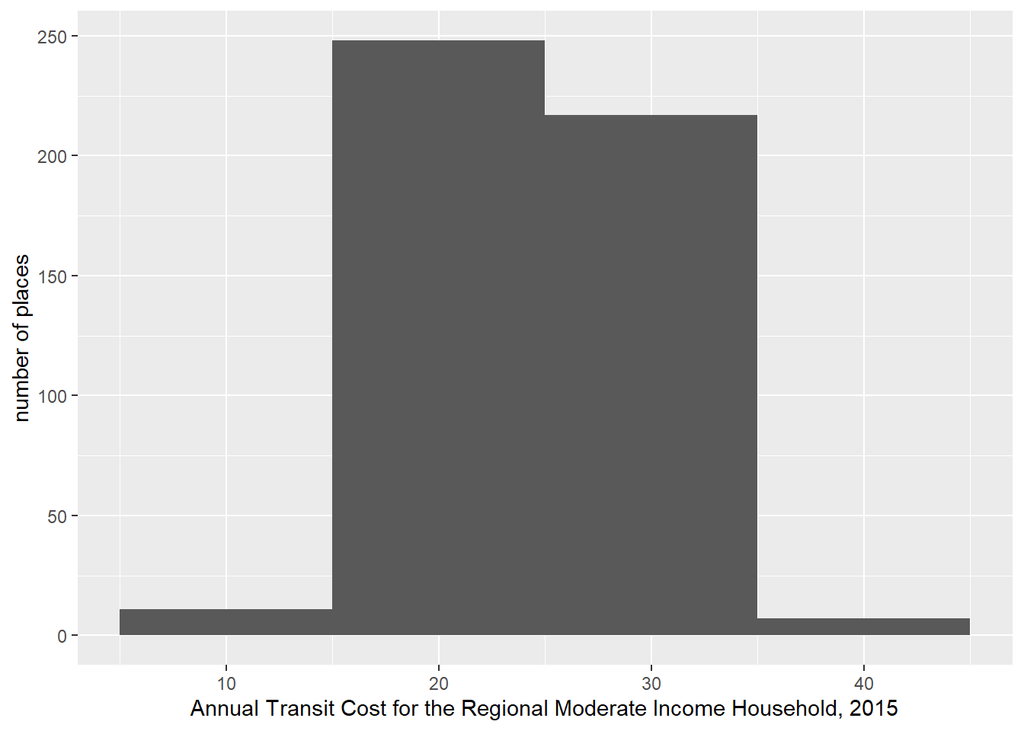

```r
ggplot(transit_cost_city_2015, aes(x=index_transportation_cost)) + geom_histogram(binwidth=10) + labs(y="number of places", x="Annual Transit Cost for the Regional Moderate Income Household, 2015")
```

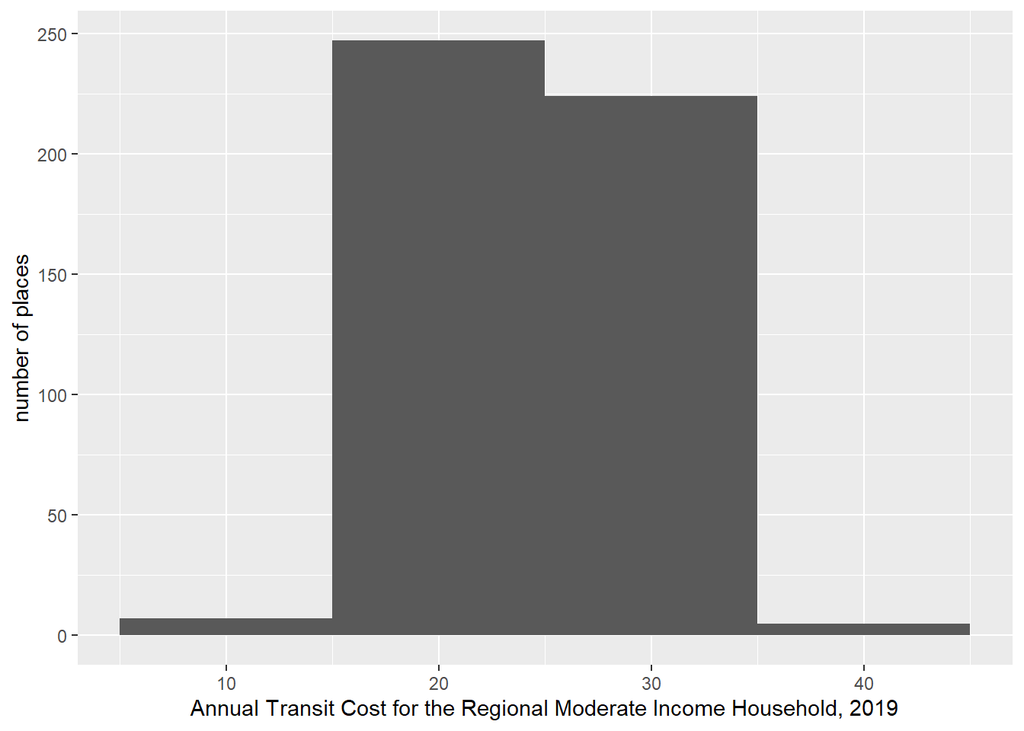

```r
ggplot(transit_cost_city_2019, aes(x=index_transportation_cost)) + geom_histogram(binwidth=10) + labs(y="number of places", x="Annual Transit Cost for the Regional Moderate Income Household, 2019")
```

look at summary stats

```r
summary(transit_cost_city_2015$index_transportation_cost)
```

```
   Min. 1st Qu.  Median    Mean 3rd Qu.    Max.    NA's
  10.58   21.91   24.80   24.57   27.30   41.44       3
```

```r
summary(transit_cost_city_2019$index_transportation_cost)
```

```
   Min. 1st Qu.  Median    Mean 3rd Qu.    Max.    NA's
  11.88   21.93   24.84   24.63   27.44   40.00       3
```

No weird outliers.

Use stopifnot to check if all values in “transit_cost_city_XXXX” are non-negative

```r
stopifnot(min(transit_cost_city_2015$index_transportation_cost, na.rm = TRUE) >= 0)
```

Good to go

```r
stopifnot(min(transit_cost_city_2019$index_transportation_cost, na.rm = TRUE) >= 0)
```

Good to go.

Find indices of missing values for the “index_transportation_cost” variable

```r
missing_indices15 <- which(is.na(transit_cost_city_2015$index_transportation_cost))
missing_indices19 <- which(is.na(transit_cost_city_2019$index_transportation_cost))
```

Print observations with missing values

```r
if (length(missing_indices15) > 0) {
  cat("Observations with missing values for index_transportation_cost:\n")
  print(transit_cost_city_2015[missing_indices15, , drop = FALSE])
} else {
  cat("No missing values for transportation_cost_county_2015\n")
}
```

```
Observations with missing values for index_transportation_cost:
# A tibble: 3 x 5
   year state place index_transportation_cost index_transportation_cost_quality
  <dbl> <chr> <chr>                     <dbl>                             <dbl>
1  2015 06    37692                        NA                                NA
2  2015 13    49008                        NA                                NA
3  2015 13    72122                        NA                                NA
```

```r
if (length(missing_indices19) > 0) {
  cat("Observations with missing values for index_transportation_cost:\n")
  print(transit_cost_city_2019[missing_indices19, , drop = FALSE])
} else {
  cat("No missing values for transportation_cost_county_2019\n")
}
```

```
Observations with missing values for index_transportation_cost:
# A tibble: 3 x 5
   year state place index_transportation_cost index_transportation_cost_quality
  <dbl> <chr> <chr>                     <dbl>                             <dbl>
1  2019 06    37692                        NA                                NA
2  2019 13    49008                        NA                                NA
3  2019 13    72122                        NA                                NA
```

## Export final files

Combine the two years into one overall files for both variables.

```r
transit_cost_city <- rbind(transit_cost_city_2015, transit_cost_city_2019) %>%
  select(year, state, place, index_transportation_cost, index_transportation_cost_quality)

transit_trips_city <- rbind(transit_trips_city_2015, transit_trips_city_2019) %>%
  select(year, state, place, index_transit_trips, index_transit_trips_quality)
```

Save as non-subgroup all-year files.

```r
write_csv(transit_cost_city, here::here("06_neighborhoods",
                                        "Transportation",
                                        "final",
                                        "transit_cost_all_city.csv"))

write_csv(transit_trips_city, here::here("06_neighborhoods",
                                         "Transportation",
                                         "final",
                                         "transit_trips_all_city.csv"))
```